# Dimensionality reduction techniques

```r
library("tidyverse")
library("ggplot2")
library("dplyr")
library("MASS")
library("corrplot")
library("GGally")


human <- read.table("data/human_.txt")
```

This week we’ll be working with some Human Development Index (HDI) data. The data was wrangled from 2 datasets: HDI and GII (gender inequality index). I combined the datasets and reduced the observations and variables to 155 and 8 respectively to clean the data from missing values etc. I also combined some variables to create more interesting ones.

So the data has now countries for rownnames and and 8 variables describing their human development.

```r
summary(human)
```

```
##  edu_2nd_ratio      lab_ratio         life_exp        edu_exp
##  Min.   :0.1717   Min.   :0.1857   Min.   :49.00   Min.   : 5.40
##  1st Qu.:0.7264   1st Qu.:0.5984   1st Qu.:66.30   1st Qu.:11.25
##  Median :0.9375   Median :0.7535   Median :74.20   Median :13.50
##  Mean   :0.8529   Mean   :0.7074   Mean   :71.65   Mean   :13.18
##  3rd Qu.:0.9968   3rd Qu.:0.8535   3rd Qu.:77.25   3rd Qu.:15.20
##  Max.   :1.4967   Max.   :1.0380   Max.   :83.50   Max.   :20.20
##    GNI.capita        mat_mort        adol_birth       parl_rep_f
##  Min.   :   581   Min.   :   1.0   Min.   :  0.60   Min.   : 0.00
##  1st Qu.:  4198   1st Qu.:  11.5   1st Qu.: 12.65   1st Qu.:12.40
##  Median : 12040   Median :  49.0   Median : 33.60   Median :19.30
##  Mean   : 17628   Mean   : 149.1   Mean   : 47.16   Mean   :20.91
##  3rd Qu.: 24512   3rd Qu.: 190.0   3rd Qu.: 71.95   3rd Qu.:27.95
##  Max.   :123124   Max.   :1100.0   Max.   :204.80   Max.   :57.50
```

- edu_2nd_ratio : ratio of females/males in secondary education
- lab_ratio : ratio of females/males in the labour force
- life_exp : life expectancy at birth
- edu_exp : expected years of education
- GNI.capita : gross national income per capita
- mat_mort : maternal mortality
- adol_birth : adolescent birth rate
- parl_rep_f : female representatives in the parliament

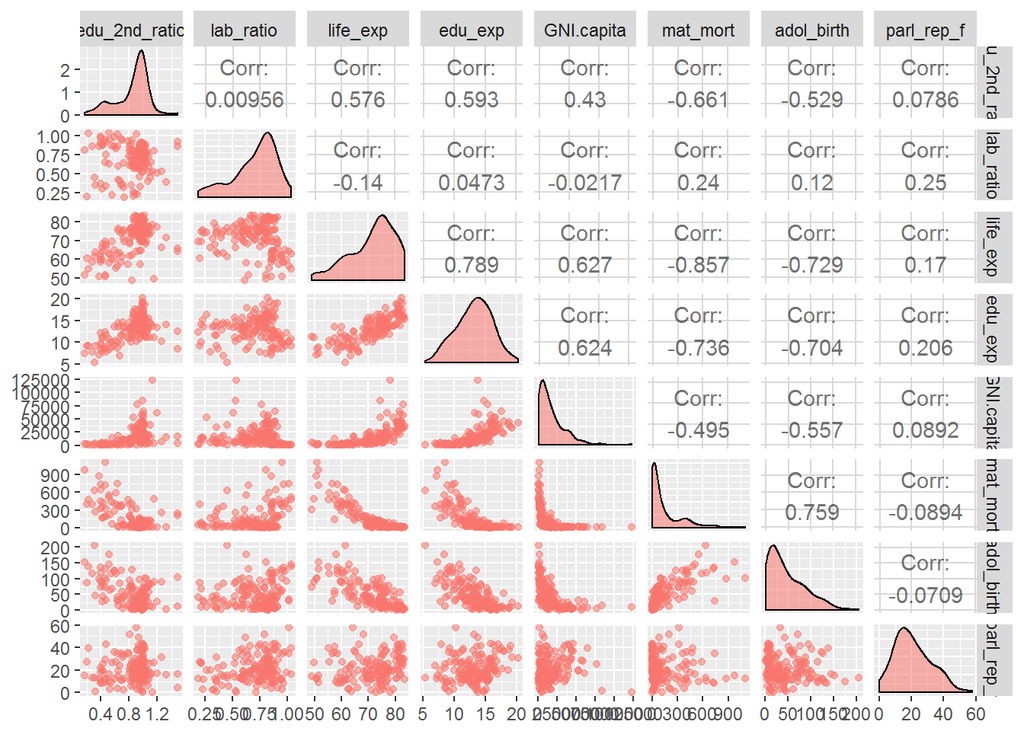

```r
ggpairs(human, aes(col="black", alpha=0.1))
```

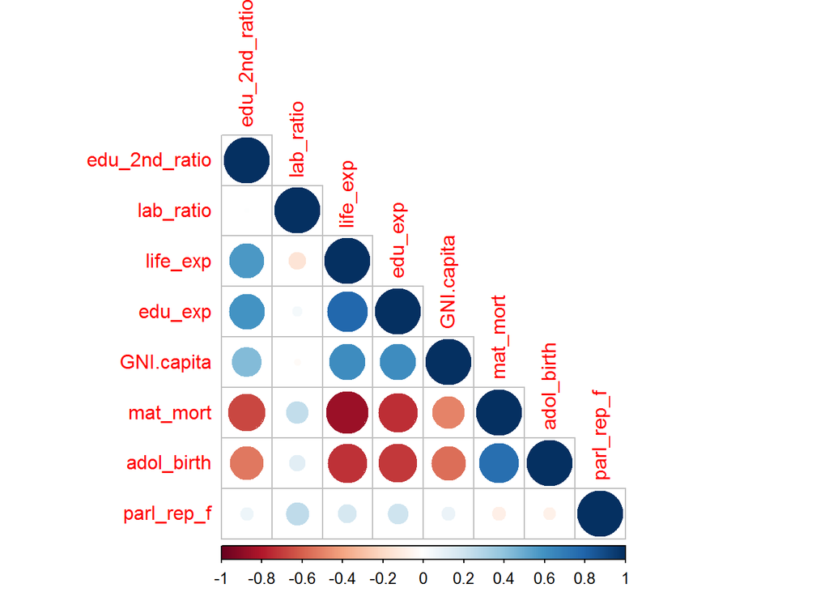

```r
corrplot(cor(human), type="lower")
```

There some high correlations in the data. Most are very obvious, for example maternal mortality having high negative correlation with life expectancy and positive with adolescent birth.

Then I’ll do the principal component analysis (PCA).

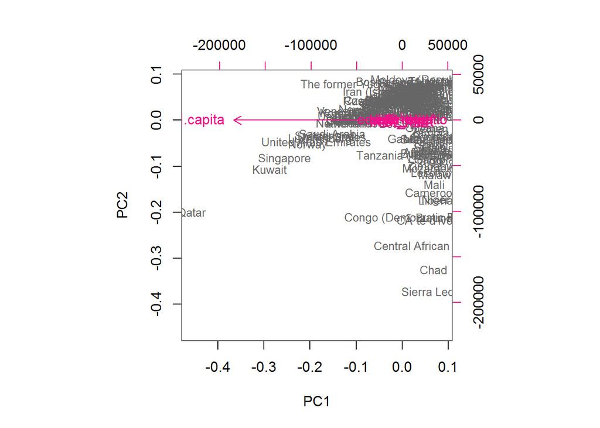

```r
# perform principal component analysis (with the SVD method)
pca_human <- prcomp(human)

# draw a biplot of the principal component representation and the original variables
biplot(pca_human, choices = 1:2, cex = c(0.8, 1), col = c("grey40", "deeppink2"))
```

Without standardization the biplot seems to be useless so let’s try that.

```r
# standardize the variables
human_std <- scale(human)

# print out summaries of the standardized variables
summary(human_std)
```

```
##  edu_2nd_ratio       lab_ratio          life_exp          edu_exp
##  Min.   :-2.8189   Min.   :-2.6247   Min.   :-2.7188   Min.   :-2.7378
##  1st Qu.:-0.5233   1st Qu.:-0.5484   1st Qu.:-0.6425   1st Qu.:-0.6782
##  Median : 0.3503   Median : 0.2316   Median : 0.3056   Median : 0.1140
##  Mean   : 0.0000   Mean   : 0.0000   Mean   : 0.0000   Mean   : 0.0000
##  3rd Qu.: 0.5958   3rd Qu.: 0.7350   3rd Qu.: 0.6717   3rd Qu.: 0.7126
##  Max.   : 2.6646   Max.   : 1.6632   Max.   : 1.4218   Max.   : 2.4730
##    GNI.capita         mat_mort         adol_birth        parl_rep_f
##  Min.   :-0.9193   Min.   :-0.6992   Min.   :-1.1325   Min.   :-1.8203
##  1st Qu.:-0.7243   1st Qu.:-0.6496   1st Qu.:-0.8394   1st Qu.:-0.7409
##  Median :-0.3013   Median :-0.4726   Median :-0.3298   Median :-0.1403
##  Mean   : 0.0000   Mean   : 0.0000   Mean   : 0.0000   Mean   : 0.0000
##  3rd Qu.: 0.3712   3rd Qu.: 0.1932   3rd Qu.: 0.6030   3rd Qu.: 0.6127
##  Max.   : 5.6890   Max.   : 4.4899   Max.   : 3.8344   Max.   : 3.1850
```

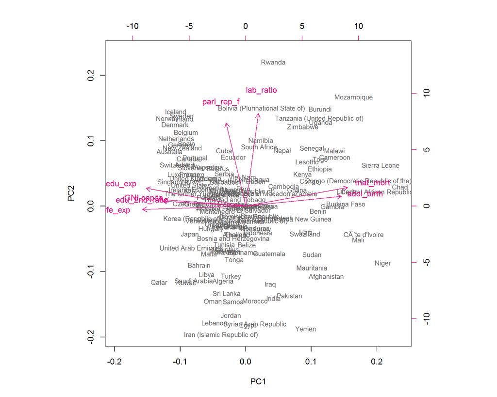

```r
# perform principal component analysis (with the SVD method)
pca_human <- prcomp(human_std)

# draw a biplot of the principal component representation and the original variables
biplot(pca_human, choices = 1:2, cex = c(0.8, 1), col = c("grey40", "deeppink2"))
```

We can see the intuitive correlations again. The developed countries are at the top left having high female labour force and parliament participation and high life and education expectancies. Struggling countries are at the opposite direction. PC1 component accounts for over 50% of the variance.